# Project: Investigate a Dataset - No Show Appointments

- Introduction
- Data Wrangling
- Exploratory Data Analysis
- Conclusions

## Introduction

### Dataset Description

This dataset collects information from 100k medical appointments in Brazil and is focused on the question of whether or not patients show up for their appointment.

### Question(s) for Analysis

**What factors are important for us to know in order to predict if a patient will show up for their scheduled appointment?**

- Is there a correlation between gender and the likelihood of a no-show in health appointments?
- Which age group does not show up for their appointments most?
- How is the gap between scheduled and appoinment day impact on no show rate?
- Are the patients with hipertension/scholarship/alcoholism/diabets less proportion to don't show up for their appointments than the others?

```python
# Use this cell to set up import statements for all of the packages that you
#   plan to use.

# Remember to include a 'magic word' so that your visualizations are plotted
#   inline with the notebook. See this page for more:
#   http://ipython.readthedocs.io/en/stable/interactive/magics.html
import numpy as np
import pandas as pd
import matplotlib.pyplot as plt
import seaborn as sns
%matplotlib inline
```

```python
# Upgrade pandas to use dataframe.explode() function.
#!pip install --upgrade pandas==0.25.0
```

## Data Wrangling

```python
# Load data and print out a few lines. Perform operations to inspect data
#   types and look for instances of missing or possibly errant data.
df = pd.read_csv('Database_No_show_appointments/noshowappointments-kagglev2-may-2016.csv')
df.head()
```

|  | PatientId | AppointmentID | Gender | ScheduledDay | AppointmentDay | Age | Neighbourhood | Scholarship | Hipertension | Diabetes | Alcoholism | Handcap | SMS_received | No-show |
| --- | --- | --- | --- | --- | --- | --- | --- | --- | --- | --- | --- | --- | --- | --- |
| 0 | 2.987250e+13 | 5642903 | F | 2016-04-29T18:38:08Z | 2016-04-29T00:00:00Z | 62 | JARDIM DA PENHA | 0 | 1 | 0 | 0 | 0 | 0 | No |
| 1 | 5.589978e+14 | 5642503 | M | 2016-04-29T16:08:27Z | 2016-04-29T00:00:00Z | 56 | JARDIM DA PENHA | 0 | 0 | 0 | 0 | 0 | 0 | No |
| 2 | 4.262962e+12 | 5642549 | F | 2016-04-29T16:19:04Z | 2016-04-29T00:00:00Z | 62 | MATA DA PRAIA | 0 | 0 | 0 | 0 | 0 | 0 | No |
| 3 | 8.679512e+11 | 5642828 | F | 2016-04-29T17:29:31Z | 2016-04-29T00:00:00Z | 8 | PONTAL DE CAMBURI | 0 | 0 | 0 | 0 | 0 | 0 | No |
| 4 | 8.841186e+12 | 5642494 | F | 2016-04-29T16:07:23Z | 2016-04-29T00:00:00Z | 56 | JARDIM DA PENHA | 0 | 1 | 1 | 0 | 0 | 0 | No |

```python
df.shape
```

```
(110527, 14)
```

```python
df.info()
```

```
<class 'pandas.core.frame.DataFrame'>
RangeIndex: 110527 entries, 0 to 110526
Data columns (total 14 columns):
PatientId         110527 non-null float64
AppointmentID     110527 non-null int64
Gender            110527 non-null object
ScheduledDay      110527 non-null object
AppointmentDay    110527 non-null object
Age               110527 non-null int64
Neighbourhood     110527 non-null object
Scholarship       110527 non-null int64
Hipertension      110527 non-null int64
Diabetes          110527 non-null int64
Alcoholism        110527 non-null int64
Handcap           110527 non-null int64
SMS_received      110527 non-null int64
No-show           110527 non-null object
dtypes: float64(1), int64(8), object(5)
memory usage: 11.8+ MB
```

```python
df.describe()
```

|  | PatientId | AppointmentID | Age | Scholarship | Hipertension | Diabetes | Alcoholism | Handcap | SMS_received |
| --- | --- | --- | --- | --- | --- | --- | --- | --- | --- |
| count | 1.105270e+05 | 1.105270e+05 | 110527.000000 | 110527.000000 | 110527.000000 | 110527.000000 | 110527.000000 | 110527.000000 | 110527.000000 |
| mean | 1.474963e+14 | 5.675305e+06 | 37.088874 | 0.098266 | 0.197246 | 0.071865 | 0.030400 | 0.022248 | 0.321026 |
| std | 2.560949e+14 | 7.129575e+04 | 23.110205 | 0.297675 | 0.397921 | 0.258265 | 0.171686 | 0.161543 | 0.466873 |
| min | 3.921784e+04 | 5.030230e+06 | -1.000000 | 0.000000 | 0.000000 | 0.000000 | 0.000000 | 0.000000 | 0.000000 |
| 25% | 4.172614e+12 | 5.640286e+06 | 18.000000 | 0.000000 | 0.000000 | 0.000000 | 0.000000 | 0.000000 | 0.000000 |
| 50% | 3.173184e+13 | 5.680573e+06 | 37.000000 | 0.000000 | 0.000000 | 0.000000 | 0.000000 | 0.000000 | 0.000000 |
| 75% | 9.439172e+13 | 5.725524e+06 | 55.000000 | 0.000000 | 0.000000 | 0.000000 | 0.000000 | 0.000000 | 1.000000 |
| max | 9.999816e+14 | 5.790484e+06 | 115.000000 | 1.000000 | 1.000000 | 1.000000 | 1.000000 | 4.000000 | 1.000000 |

```python
df.duplicated().sum()
```

```
0
```

```python
df.Handcap.unique()
```

```
array([0, 1, 2, 3, 4])
```

```python
df.SMS_received.unique()
```

```
array([0, 1])
```

```python
df['No-show'].unique()
```

```
array(['No', 'Yes'], dtype=object)
```

### Here are some observations:

- Since the columns **PatientId** and **AppointmentID** are more patient-specific, it is ok to remove these two columns.
- There is an invalid age recorded as -1, which is not a valid age value.
- The **Handcap** column should ideally have True/False (or 0/1) values. However, there are a few records that display values of 2/3/4. It is recommended to drop these records.
- Just minor but it is customary to follow the convention of naming columns in lowercase with underscores
- Scheduled Day and Appointment Day are in string format, we can change to datetime to count days interval

### Data Cleaning

```python
df.drop(['PatientId', 'AppointmentID'], axis=1, inplace=True)
df.head()
```

|  | Gender | ScheduledDay | AppointmentDay | Age | Neighbourhood | Scholarship | Hipertension | Diabetes | Alcoholism | Handcap | SMS_received | No-show |
| --- | --- | --- | --- | --- | --- | --- | --- | --- | --- | --- | --- | --- |
| 0 | F | 2016-04-29T18:38:08Z | 2016-04-29T00:00:00Z | 62 | JARDIM DA PENHA | 0 | 1 | 0 | 0 | 0 | 0 | No |
| 1 | M | 2016-04-29T16:08:27Z | 2016-04-29T00:00:00Z | 56 | JARDIM DA PENHA | 0 | 0 | 0 | 0 | 0 | 0 | No |
| 2 | F | 2016-04-29T16:19:04Z | 2016-04-29T00:00:00Z | 62 | MATA DA PRAIA | 0 | 0 | 0 | 0 | 0 | 0 | No |
| 3 | F | 2016-04-29T17:29:31Z | 2016-04-29T00:00:00Z | 8 | PONTAL DE CAMBURI | 0 | 0 | 0 | 0 | 0 | 0 | No |
| 4 | F | 2016-04-29T16:07:23Z | 2016-04-29T00:00:00Z | 56 | JARDIM DA PENHA | 0 | 1 | 1 | 0 | 0 | 0 | No |

We are dropping two columns which are not relevant to our analysis

```python
# drop records which invalid Age
df = df[df['Age'] >= 0]
```

According to describe() method, there is record with min value of Age is -1, which is invalid record. We should clean it up

```python
df = df[df['Handcap'] <= 1]
```

Handcap should be 0 or 1 (means False / True)

```python
new_column_names = {'Gender': 'gender',
                    'ScheduledDay': 'scheduled_day',
                    'AppointmentDay': 'appointment_day',
                    'Age': 'age',
                    'Neighbourhood': 'neighbourhood',
                    'Scholarship': 'scholarship',
                    'Hipertension': 'hipertension',
                    'Diabetes': 'diabetes',
                    'Alcoholism': 'alcoholism',
                    'Handcap': 'handcap',
                    'SMS_received': 'sms_received',
                    'No-show': 'no_show'
                   }

df.rename(columns=new_column_names, inplace=True)
df.head()
```

|  | gender | scheduled_day | appointment_day | age | neighbourhood | scholarship | hipertension | diabetes | alcoholism | handcap | sms_received | no_show |
| --- | --- | --- | --- | --- | --- | --- | --- | --- | --- | --- | --- | --- |
| 0 | F | 2016-04-29T18:38:08Z | 2016-04-29T00:00:00Z | 62 | JARDIM DA PENHA | 0 | 1 | 0 | 0 | 0 | 0 | No |
| 1 | M | 2016-04-29T16:08:27Z | 2016-04-29T00:00:00Z | 56 | JARDIM DA PENHA | 0 | 0 | 0 | 0 | 0 | 0 | No |
| 2 | F | 2016-04-29T16:19:04Z | 2016-04-29T00:00:00Z | 62 | MATA DA PRAIA | 0 | 0 | 0 | 0 | 0 | 0 | No |
| 3 | F | 2016-04-29T17:29:31Z | 2016-04-29T00:00:00Z | 8 | PONTAL DE CAMBURI | 0 | 0 | 0 | 0 | 0 | 0 | No |
| 4 | F | 2016-04-29T16:07:23Z | 2016-04-29T00:00:00Z | 56 | JARDIM DA PENHA | 0 | 1 | 1 | 0 | 0 | 0 | No |

Renaming columns to make it naming consistent

```python
# Count day intervals
df['scheduled_day'] = pd.to_datetime(df['scheduled_day'])
df['scheduled_day'] = df['scheduled_day'].dt.date
df['appointment_day'] = pd.to_datetime(df['appointment_day'])
df['appointment_day'] = df['appointment_day'].dt.date
df['day_interval'] = (df['appointment_day'] - df['scheduled_day']).dt.days
df.head()
```

|  | gender | scheduled_day | appointment_day | age | neighbourhood | scholarship | hipertension | diabetes | alcoholism | handcap | sms_received | no_show | day_interval |
| --- | --- | --- | --- | --- | --- | --- | --- | --- | --- | --- | --- | --- | --- |
| 0 | F | 2016-04-29 | 2016-04-29 | 62 | JARDIM DA PENHA | 0 | 1 | 0 | 0 | 0 | 0 | No | 0 |
| 1 | M | 2016-04-29 | 2016-04-29 | 56 | JARDIM DA PENHA | 0 | 0 | 0 | 0 | 0 | 0 | No | 0 |
| 2 | F | 2016-04-29 | 2016-04-29 | 62 | MATA DA PRAIA | 0 | 0 | 0 | 0 | 0 | 0 | No | 0 |
| 3 | F | 2016-04-29 | 2016-04-29 | 8 | PONTAL DE CAMBURI | 0 | 0 | 0 | 0 | 0 | 0 | No | 0 |
| 4 | F | 2016-04-29 | 2016-04-29 | 56 | JARDIM DA PENHA | 0 | 1 | 1 | 0 | 0 | 0 | No | 0 |

```python
df = df[df.day_interval >= -1]
df.day_interval = df.day_interval.replace(-1, 0)
```

```python
df.head()
```

|  | gender | scheduled_day | appointment_day | age | neighbourhood | scholarship | hipertension | diabetes | alcoholism | handcap | sms_received | no_show | day_interval |
| --- | --- | --- | --- | --- | --- | --- | --- | --- | --- | --- | --- | --- | --- |
| 0 | F | 2016-04-29 | 2016-04-29 | 62 | JARDIM DA PENHA | 0 | 1 | 0 | 0 | 0 | 0 | No | 0 |
| 1 | M | 2016-04-29 | 2016-04-29 | 56 | JARDIM DA PENHA | 0 | 0 | 0 | 0 | 0 | 0 | No | 0 |
| 2 | F | 2016-04-29 | 2016-04-29 | 62 | MATA DA PRAIA | 0 | 0 | 0 | 0 | 0 | 0 | No | 0 |
| 3 | F | 2016-04-29 | 2016-04-29 | 8 | PONTAL DE CAMBURI | 0 | 0 | 0 | 0 | 0 | 0 | No | 0 |
| 4 | F | 2016-04-29 | 2016-04-29 | 56 | JARDIM DA PENHA | 0 | 1 | 1 | 0 | 0 | 0 | No | 0 |

## Exploratory Data Analysis

```python
df_noshow = df[df.no_show == 'Yes']

def plot_stack(factor, ax=None):
    '''
    docstring: Create a stacked chart to show statistic of given factor and show/no-show rate
    inputs: factor
    output:...
    '''
    group_df = df.groupby(factor)['no_show'].value_counts(normalize=True).mul(100).unstack()

    if not ax:
        fig, ax = plt.subplots(nrows=1,ncols=1, figsize=[14,5]);

    plot = group_df.plot(kind='bar', ax=ax, stacked=True, rot=0)

    for col in group_df:
        for i, value in enumerate(group_df[col]):
            plot.text(i, 100 - value, f'{value:.2f}%', ha='center', va='bottom', color='white', weight='bold')

    plot.set_title(f'Percentage show/no-show: {factor}'.title(), fontsize=12, weight='bold')
    plot.set_ylabel('Percentage')
    plot.set_xlabel(factor.title())
    plot.legend(labels=['Show Up', 'No Show'])

def plot_line(factor):
    '''
    docstring: Create a line chart to distribution of factor
    inputs: factor
    output:...
    '''
    grouped_df = df.groupby([factor, 'no_show']).size().unstack()

    absence_rate_percentage = (grouped_df['Yes'] / grouped_df.sum(axis=1)) * 100

    # Plotting the bar chart with percentage labels
    fig, ax = plt.subplots(figsize=(20, 6))
    absence_rate_percentage.plot(kind='line', ax=ax)

    # Customizing the plot if needed
    plt.title('Percentage of No Show Rate by {}'.format(factor), fontsize=16, weight='bold')
    plt.xlabel(factor.capitalize())
    plt.ylabel('No Show Percentage')
    plt.xticks(range(df[factor].min(), df[factor].max(), 5))
    plt.axhline(y=absence_rate_percentage.mean(), color="Green", linestyle='--', label='Average No Show Percentage')

    # Display the plot
    plt.show()

def plot_pie(df, factor, palette=None, explode=[0,0.1], ax=None, labels=None):
    '''
    docstring: Create a pie chart to statistic of given factor
    inputs:...
    output:...
    '''
    if not labels:
        labels=[f'Without {factor}', f'With {factor}']
    if not ax:
        fig, ax = plt.subplots(nrows=1,ncols=1, figsize=[14,5]);
    plot = df[factor].value_counts().plot(kind='pie', ax=ax, explode=explode, autopct='%1.2f%%',
                                         labels=labels,
                                         startangle=90, counterclock=False)
    plot.set_title(f'Distribution of {factor}'.title(), fontsize=12, weight='bold')
    plot.set_ylabel('')
    plot.axis('equal')
    plot.legend(title=factor.title());
```

We defined three reusable methods for creating same plot under different factors.

First we will create plots for all the categorical values (univariate analysis):

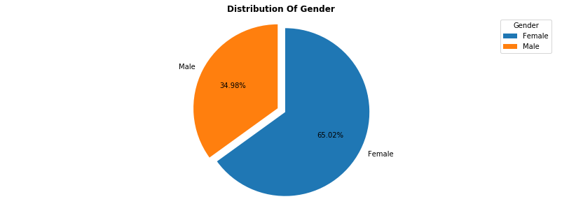

```python
plot_pie(df, 'gender', labels=['Female', 'Male'])
```

We are having a dataset where the distribution of genders is unequal, with approximately 65% female and 35% male.

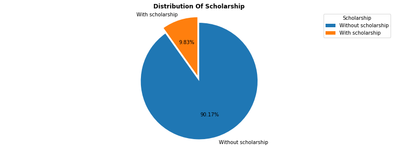

```python
plot_pie(df, 'scholarship')
```

In this dataset, there are two distinct groups: one with welfare and one without welfare. The ratio between these groups is approximately 9:1, indicating a significant imbalance.

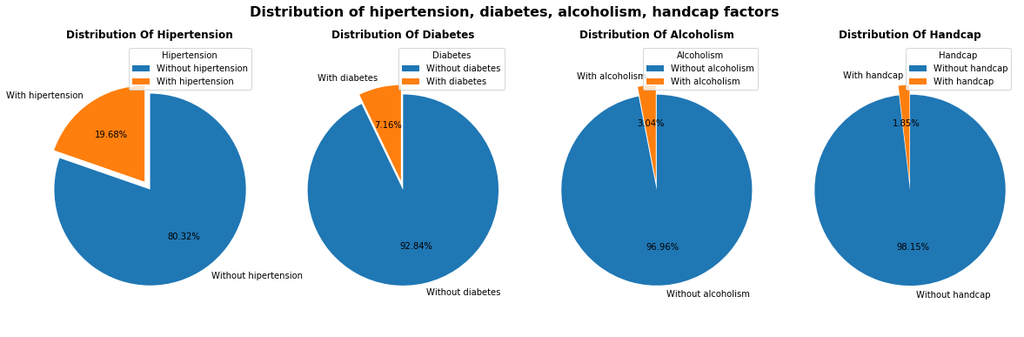

```python
columns = ['hipertension', 'diabetes', 'alcoholism', 'handcap']

fig, axes = plt.subplots(nrows=1, ncols=len(columns), figsize=(20, 6))

for i, column in enumerate(columns):
    plot_pie(df, column, ax=axes[i])

plt.suptitle(f'Distribution of {", ".join(columns)} factors', fontsize=16, weight='bold');
```

Additionally, we have an strongly unequal distribution of individuals with diseases/disabilities in our dataset. Especially in disabilities group with ratio of 2%.

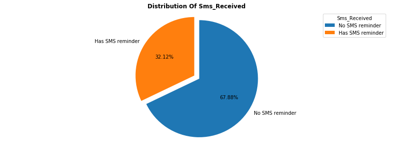

```python
plot_pie(df, 'sms_received', labels=['No SMS reminder', 'Has SMS reminder'])
```

However, when considering the ratio between patients who received a message and those who did not, it is slightly better, with approximately 33% receiving a message and 67% not receiving a message. They must be trying to apply the technology there to improve patient experience.

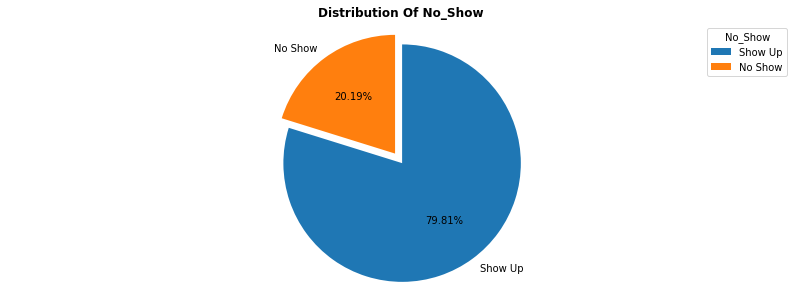

```python
plot_pie(df, 'no_show', labels=['Show Up', 'No Show'])
```

From the dataset containing approximately 110,000 records, it is evident that there is an unequal distribution of values within the factor being examined. For instance, we observe that No Show rate accounts for 20% of the dataset compared to 80% for Show rate. Additionally, there is a significant disparity in the representation of alcoholism, with a ratio of 97:3. This uneven distribution could potentially pose limitations to our analysis.

### Research Question 1: Is there a correlation between gender and the likelihood of a no-show in health appointments?

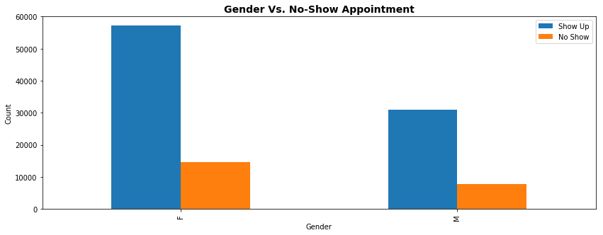

```python
df.groupby(['gender', 'no_show']).size().unstack().plot.bar(figsize=[14,5])

plt.title('Gender vs. No-show Appointment')
plt.legend(labels=['Show Up', 'No Show'])
plt.xlabel('Gender')
plt.ylabel('Count')
plt.title(f'Gender vs. No-show Appointment'.title(), weight='bold', fontsize=14)

plt.show()
```

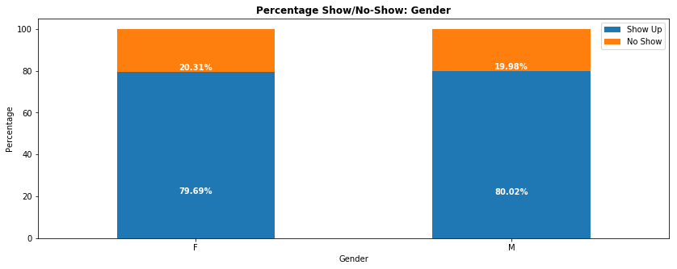

```python
plot_stack('gender')
```

Upon comparing the no-show rates between males and females, we did not find any significant discrepancies. However, upon closer examination of the calculations, we observe that, on average, women tend to miss appointments 0.33% more often than males.

### Research Question 2: Which age group does not show up for their appointments most?

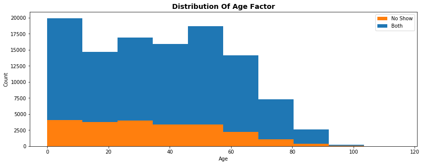

```python
df.age.hist(figsize=[14,5]);
df_noshow.age.plot.hist(figsize=[14,5])
plt.xlabel('Age')
plt.ylabel('Count')
plt.title(f'Distribution of Age factor'.title(), weight='bold', fontsize=14)
plt.legend(labels=['No Show', 'Both'])
plt.show()
```

Based on the visualization, it is evident that the highest number of patients falls within the age group of children under 10 years. Additionally, there is another noticeable peak in the age range between 50 and just under 60. However, we could see the difference of No Show rate between ages.

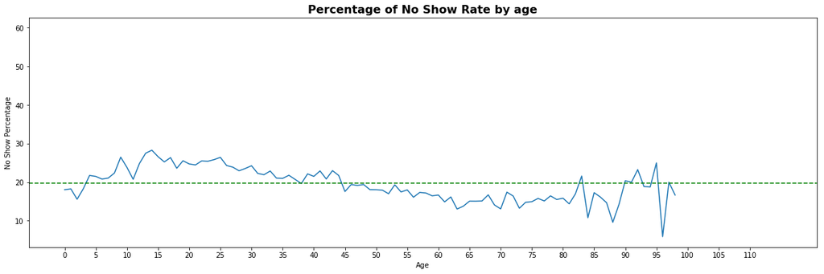

```python
plot_line('age');
```

Analyzing the graph, we observe a distinct pattern in the absence rates among different age groups. Initially, patients below the age of 5 exhibit a notably low absence rate (below mean value of ~20%). As the age increases, the absence rate begins to rise more than ~20% until around age 45, where it starts to decline. Following that, we notice a gradual decrease in the absence rate from 45 years old.

### Research Question 3: How is the gap between scheduled and appoinment day impact on no show rate?

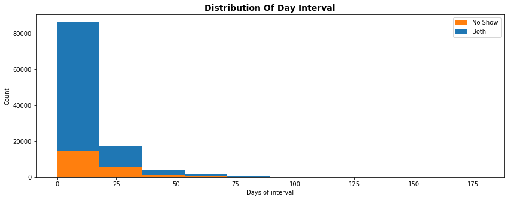

```python
df.day_interval.hist(figsize=[14,5]);
df_noshow.day_interval.plot.hist(figsize=[14,5])
plt.xlabel('Days of interval')
plt.ylabel('Count')
plt.title(f'Distribution of Day Interval'.title(), weight='bold', fontsize=14)
plt.legend(labels=['No Show', 'Both'])
plt.show()
```

For most of the data, the days between the scheduled and the appointment day is less than 25 days

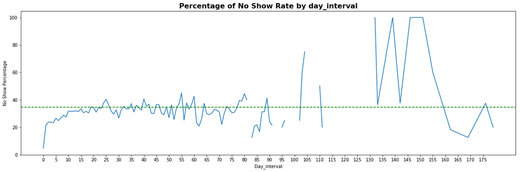

```python
plot_line('day_interval')
```

Based on the graph, it is evident that a shorter time gap between the scheduled day and the appointment day is associated with a lower no-show rate. We observe a gradual increase (5% to ~35%) in the no-show rate for gaps ranging from 0 to 25 days. However, when the gap extends beyond a month, the data does not strongly support this trend.

### Research Question 4: Are the patients with hipertension/scholarship/alcoholism/diabets less proportion to don't show up for their appointments than the others?

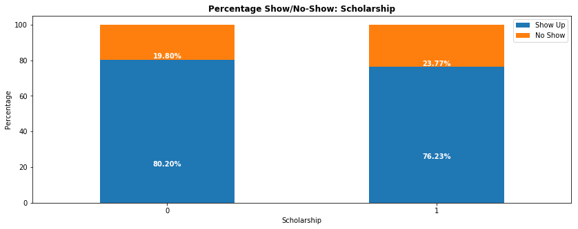

```python
plot_stack('scholarship')
```

It is evident now that those who received scholarship, tend to miss the appointment than those who didn’t receive it. However, it is just about 4%.

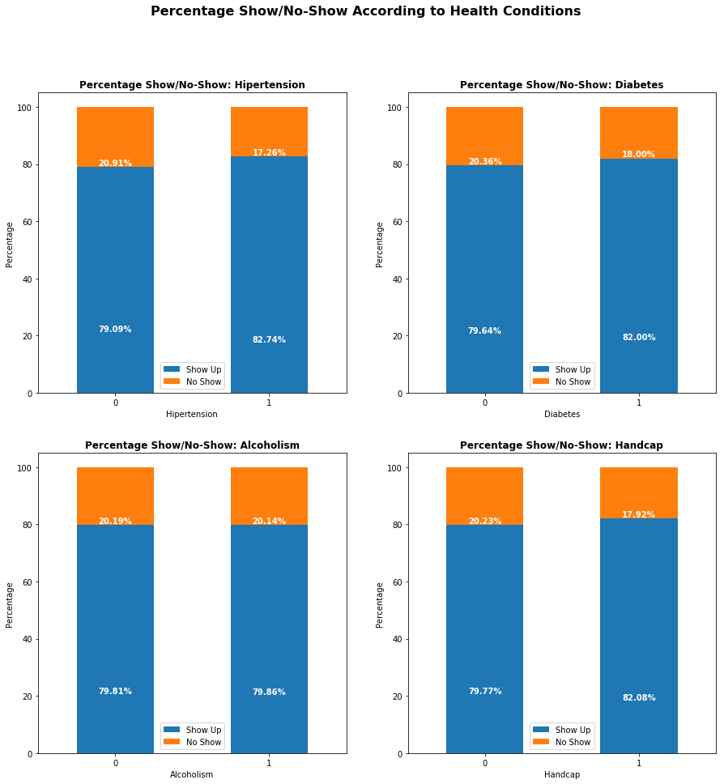

```python
columns = ['hipertension', 'diabetes', 'alcoholism', 'handcap']

fig, axes = plt.subplots(nrows=2, ncols=2, figsize=(15, 15))

for i in range(len(columns)):
    row = i // 2  # Row index
    col = i % 2   # Column index
    plot_stack_1(columns[i], ax=axes[row, col])

plt.suptitle(f'Percentage Show/No-Show According to Health Conditions', fontsize=16, weight='bold');
```

There is no significant association between diabetes, alcoholism, hypertension, and the likelihood of patients missing their appointments.

Upon examining the four distinct health conditions, we observe that the variance in absence rates is relatively minimal. Among them, the highest absence rate recorded is 20.14%, linked to patients with alcoholism. Conversely, the lowest absence rate is 17.26%, observed among patients with hypertension. However, it is crucial to consider that the distribution of visits across these conditions is not uniform within the total number of visits.

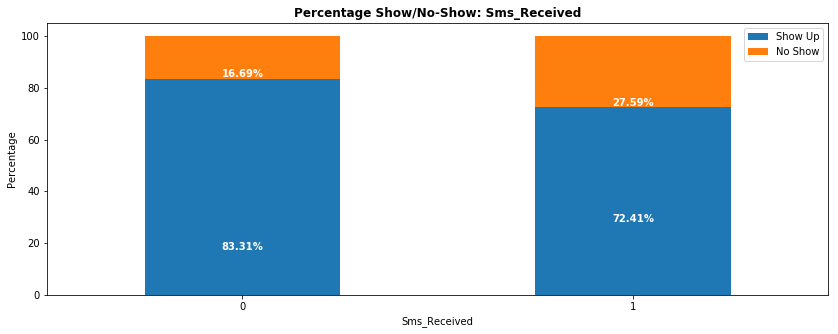

```python
plot_stack('sms_received')
```

It is evident from the data that patients who received SMS notifications have a higher rate of not showing up (~28%) for their appointments compared to those who did not receive such notifications. It's interesting fact!

## Conclusions

Based on my exploratory data analysis (EDA) of the dataset, I have identified several variables that exhibit associations, to some extent, with the likelihood of patients showing up for their appointments:

- There is no significant distinction between male and female patients in terms of not showing up for their appointments. The proportions of non-attendance are similar for both genders (20.31% and 19.98%), indicating that gender alone does not play a differentiating role in predicting no-shows.
- Both toddlers (0-5 years old) and seniors (over 45 years old) exhibit a higher likelihood of patients showing up for their appointments with the absence rate below medium (20%) compared to other age groups. This can be attributed to the fact that people tend to prioritize their health conditions more during these particular stages of life.
- It is important to minimize the waiting time for appointments. Prolonged waiting periods may result in patients either recovering or forgetting about their scheduled appointments.
- Furthermore, there are some noteworthy findings that require further attention:
  - Surprisingly, patients who received SMS reminders for their appointments had a higher likelihood of missing their appointments. Thus, allocating resources and time towards sending SMS notifications may not have a positive effect, but instead have a negative impact. Budget and resources can be saved by reconsidering the use of SMS reminders.
  - Individuals enrolled in the special Bolsa Familia program or those with the Scholarship variable marked as TRUE showed a higher (4%) tendency to not show up for their appointments.

One limitation of this analysis is the unequal distribution between the female and male populations, as well as potentially other factors.

To address this issue and mitigate its impact, it would be beneficial to obtain a larger sample size to achieve a more balanced representation across the various factors under consideration. By obtaining more data, we can aim to fill the gaps in the distribution and improve the overall validity and reliability of the analysis.

## Submitting your Project

```python
from subprocess import call
call(['python', '-m', 'nbconvert', 'Investigate_a_Dataset.ipynb'])
```

```
0
```